# Reproducible Research: Peer Assessment 1

## Introduction

This assignment makes use of data from a personal activity monitoring device. This device collects data at 5 minute intervals through out the day. The data consists of two months of data from an anonymous individual collected during the months of October and November, 2012 and include the number of steps taken in 5 minute intervals each day.

## Loading and preprocessing the data

In this project, the following assumptions are made:  
1. Packages *“ggplot2”, dplyr“,”data.table"* are already installed 2. Data archive file *activity.zip* is already downloaded and present in CWD

In this section the following steps are executed: 1. unzip **activity.zip** and load **activity.csv** file 2. Process/transform the data (if necessary) into a format suitable for your analysis

1. unpack ‘activity.zip’ and load ‘activity.csv’
2. Load data as two Data Frames

```r
zipFile <- "https://d396qusza40orc.cloudfront.net/repdata%2Fdata%2Factivity.zip"
zipFileName <- "activity.zip"
if (!file.exists(zipFileName)){
  download.file(zipFile, zipFileName, mode = "wb")
}

unzip(zipFileName, exdir = getwd())

csv_file <- read.csv2(file="activity.csv", sep="," , header=TRUE)
csv_file1 <- read.csv2(file="activity.csv", sep="," , header=TRUE)
setDT(csv_file)
setDT(csv_file1)
```

## What is mean total number of steps taken per day?

In this part of the section, we ignore the missing values in the dataset.  
1. Calculate the total number of steps taken per day

```r
## Step 1: Convert 'date' from 'character' to 'Date'
csv_file$date <- as.Date(csv_file$date, format="%Y-%m-%d")

## Step 2: Group by date to create plot and add steps taken in a day
plot_steps <- csv_file %>% group_by(date) %>% summarize(steps = sum(steps))
```

2. Plot a histogram of the total number of steps taken each day

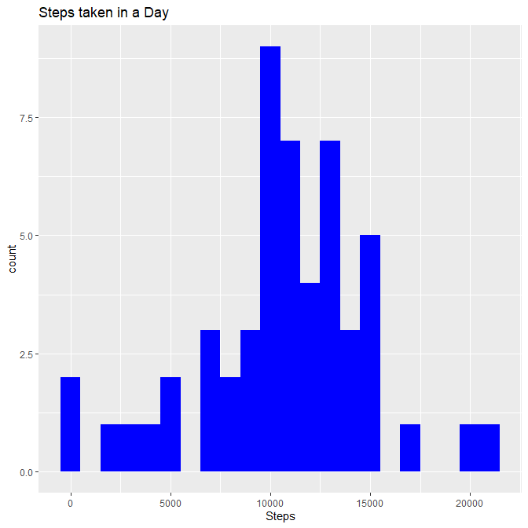

```r
ggplot(plot_steps, aes(x = steps)) + geom_histogram(fill = "blue", binwidth = 1000) + labs(title = "Steps taken in a Day", x = "Steps")
```

3. Calculate and report the mean and median of the total number of steps taken per day

```r
mean_steps <- mean(plot_steps$steps, na.rm=TRUE)
median_steps <- median(plot_steps$steps, na.rm=TRUE)
```

Mean 1.0766189^{4} number of total number of steps taken per day Median 10765 number of total number of steps taken per day

## What is the average daily activity pattern?

In this part of the section, code executes the following steps: 1. Make a time series plot (i.e. ) of the 5-minute interval (x-axis) and the average number of steps taken, averaged across all days (y-axis)

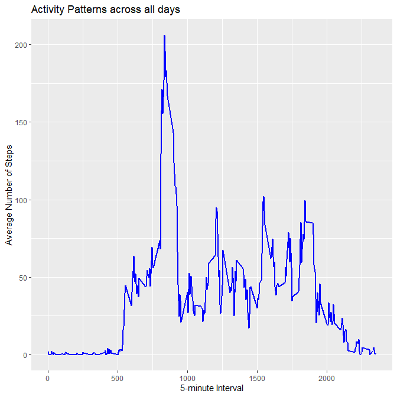

```r
stepsByInterval <- csv_file1 %>% group_by(interval) %>% summarize(steps = mean(steps, na.rm=TRUE))

# filter the stepsByInterval where steps is maximum
maxRow <- stepsByInterval[which.max(stepsByInterval$steps),]

titlelab <- "Activity Patterns across all days"
ylab <- "Average Number of Steps"
xlab <- "5-minute Interval"

g <- ggplot(stepsByInterval, aes(x=interval, y=steps)) +geom_line(color="blue", size=1)
g + labs(x = xlab) + labs(y = ylab) + labs(title = titlelab)
```

2. Which 5-minute interval, on average across all the days in the dataset, contains the  
   maximum number of steps?  
   Maximum Number of Steps 206.1698113  
   Interval that contains the maximum number of steps: 835

## Imputing missing values

In this part of the section, code executes the following steps:

1. Calculate and report the total number of missing values in the dataset (i.e. the total number of rows with NA)

```r
num_of_NAs_in_rows <- apply(csv_file1, 1, function(x){any(is.na(x))})
```

Total number of missing values in the dataset: 2304

2. Devise a strategy for filling in all of the missing values in the dataset. The strategy does not need to be sophisticated. For example, you could use the mean/median for that day, or the mean for that 5-minute interval, etc.
3. Create a new dataset that is equal to the original dataset but with the missing data filled in.

```r
## Filling missing values in 'stpes' with median of 'steps'
## new dataset 'csv_file1' created

csv_file1$steps[is.na(csv_file1$steps)] <- median(csv_file1$steps, na.rm=TRUE)

## Step 1: Convert 'date' from 'character' to 'Date'
csv_file1$date <- as.Date(csv_file1$date, format="%Y-%m-%d")

## Step 2: Group by date to create plot and add steps taken in a day
plot_steps <- csv_file1 %>% group_by(date) %>% summarize(steps = sum(steps))
```

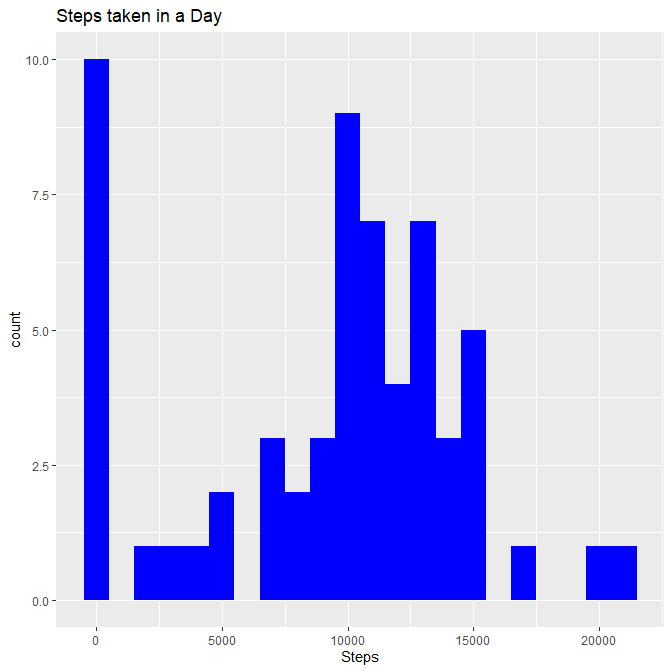

```r
ggplot(plot_steps, aes(x = steps)) + geom_histogram(fill = "blue", binwidth = 1000) + labs(title = "Steps taken in a Day", x = "Steps")
```

## Are there differences in activity patterns between weekdays and weekends?

In this part of the section, code executes the following steps:

1. Create a new factor variable in the dataset with two levels – “weekday” and “weekend indicating whether a given date is a weekday or weekend day.

```r
## Add DayofWeek column
csv_file1 <- mutate(csv_file1, DayofWeek = weekdays(csv_file1$date))

## Function to add 'weekday_or_weekend column to plot
## credit: https://stackoverflow.com/questions/38649533/case-when-in-mutate-pipe
## credit: https://www.statology.org/conditional-mutating-r/
set_weekdays_weekend <- function(df) {
    df %>% mutate(weekday_or_weekend = case_when(
        DayofWeek == "Monday" ~ "weekday",
        DayofWeek == "Tuesday" ~ "weekday",
        DayofWeek == "Wednesday" ~ "weekday",
        DayofWeek == "Thursday" ~ "weekday",
        DayofWeek == "Friday" ~ "weekday",
        DayofWeek == "Saturday" ~ "weekend",
        DayofWeek == "Sunday" ~ "weekend",
    ))
}

## Add two more columns -- weekend and weekday
csv_file1 <- set_weekdays_weekend(csv_file1)

plot_weekend_weekday <- csv_file1 %>% group_by(interval, weekday_or_weekend) %>% summarize(steps = mean(steps))
```

2. Panel plot containing a time series plot (i.e. ) of the 5-minute interval (xaxis) and the average number of steps taken, averaged across all weekday days or weekend days (y-axis).

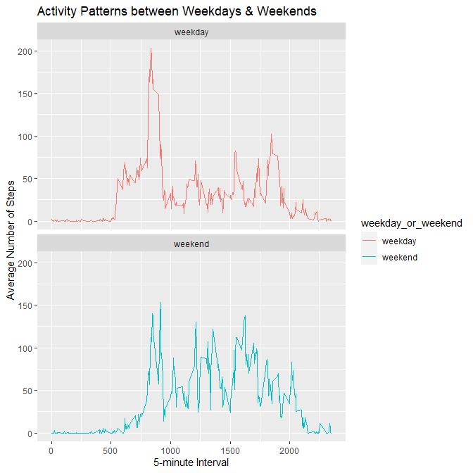

```r
titlelab <- "Activity Patterns between Weekdays & Weekends"
ylab <- "Average Number of Steps"
xlab <- "5-minute Interval"

g <- ggplot(plot_weekend_weekday, aes(x=interval, y=steps, color=weekday_or_weekend))
g + geom_line() + labs(x = xlab) + labs(y = ylab) + labs(title = titlelab) + facet_wrap(~weekday_or_weekend, ncol =1, nrow=2)
```

Are there differences in activity patterns between weekdays and weekends?  
* **YES**